# Module 6 - Team Project: Final Report

**ALY6015: Intermediate Analytics**

**Module 6 — Team Project: Final Report**

Group 3 Pei-Yu Jheng, Phuong Mai Dan Nguyen, Sumate Boonchitbanchong

Instructor: Vladimir Shapiro

Winter Semester Sec 09

## **Introduction**

Success in competitive sports necessitates a combination of strategic thought, individual talent, and successful teamwork. Basketball, a riveting blend of strategy and skill, embodies the never-ending chase of win, with every dribble, pass, and shot having the potential to change the course of a game and shape an entire season.

This investigation delves into the complex dynamics of basketball performance to identify the keys to success. We use statistical analysis to understand how player performance, game conditions, and team dynamics impact athletic achievement.

## **Method**

Table 1 : Business Questions and Methods

| Business Question | Method |
| --- | --- |
| **BQ1**: Test whether the mean points per minute are equal between close games and non-close games | t-test |
| **BQ2**: Test whether the mean points per minute differ across different opponent teams | ANOVA |
| **BQ3**: Test whether winning percentage by year is independent on game score levels | Chi-square of independence |
| **BQ4**: Predict the binary outcome variable’successYes/No’ | Logistic Regression |
| **BQ5**: Predict the binary outcome variable ‘win’ | Logistic Regression |
| **BQ6**: Predict the points per minute variable | Lasso Regression |

**BQ1 allows us to compare the performance of Michael Jordan in close games versus non-close games.**

A close game or non-close game compute by the “diff” variable. A close game defines as a game where the difference in points between the winning and losing teams is equal or less than 5 points.

**M1: By conducting a t-test, we can determine if there is a statistically significant difference in mean points per minute between these two game situations.**

Understanding these differences can shed light on how player perform under different levels of pressure or intensity.

**BQ2 investigates how Michael Jordan’s performance varies across different opponent teams.**

**M2: ANOVA is appropriate for comparing means across multiple groups, making it a suitable choice for assessing differences in points per minute among various opponents of Michael Jordan.**

This information is valuable for understanding matchup dynamics and identifying teams that may pose particular challenges or opportunities for players.

**BQ3 explores the relationship between winning percentage by year and its independence on game score levels.**

**M3 involves the Chi-square Test of independence, providing insights into how game score performance may depend on winning percentage by year.**

**BQ4 focuses on understanding the factors that contribute to long-term player success.**

**M4: Logistic Regression is applied to predict whether a player will achieve success based on their early career statistics.**

By analyzing the predictors associated with success, such as performance metrics and game locations, we can identify key factors influencing a player’s trajectory.

**BQ5 predicts the binary outcome of individual game wins or losses.**

**M5: Logistic Regression is utilized to model the likelihood of a team winning a game based on various factors which are various variables within Michael Jordan’s dataset.**

By understanding the predictors associated with winning outcomes, teams can make informed decisions to improve their chances of success on the court.

**BQ6 forecasts the continuous variable of points per minute.**

**M6: Lasso Regression allows us to not only predict points per minute but also to identify the most influential factors affecting a player’s scoring efficiency during games.**

By shrinking certain regression coefficients to zero, Lasso regression provides insight into the most impactful features to formulate strategies to maximize scoring output and optimize player performance for maximizing offensive potential.

Clears console

```r
cat("\014") # clears console
rm(list = ls()) # clears global environment
try(dev.off(dev.list()["RStudioGD"]), silent = TRUE) # clears plots
try(p_unload(p_loaded(), character.only = TRUE), silent = TRUE) # clears packages
options(scipen = 100) # disables scientific notation for entire R session
```

Import libraries

```r
library(pacman)
p_load(ggplot2)
p_load(ggthemes)
p_load(tidyverse)
p_load(lubridate)
p_load(ggeasy)
p_load(janitor)
p_load(dplyr)
p_load(tibble)
p_load(skimr)
p_load(cowplot)     #plot_grid
p_load(car)
p_load(corrplot)
p_load(ggcorrplot)
p_load(RColorBrewer)

p_load(knitr)           #table caption
p_load(ROSE)            #ovun.sample

p_load(smbinning)       #smbinning
p_load(caret)           #createDataPartition function
p_load(glmnet)
p_load(Metrics)
p_load(pROC)            #area under the curve
p_load(MKclass)         #optCutoff()
```

Import Dataset

```r
#obtain the current work directory path
current_wd = getwd()

#add the dataset name
full_path_csv = paste(current_wd, "michael-jordan-nba-career-regular-season-stats-by-game.csv", sep="/")
#full_path_csv

#import csv
Michael_df <- read_csv(full_path_csv)
Michael_df <- clean_names(Michael_df)

#Add missing data
#x3p_pct = 0
Michael_df$x3p_pct[is.na(Michael_df$x3p_pct) & Michael_df$x3pa == 0] <- 0

#ft_pct = 0
Michael_df$ft_pct[is.na(Michael_df$ft_pct) & Michael_df$fta == 0] <- 0

#Additional Variables
Michael_df <- Michael_df %>%
  mutate(close_game = ifelse(abs(diff) <= 5, 1, 0)) %>%
  mutate(pts_per_minute = pts / mp)

#Remove irrelevant variables
selected_columns <- c('rk', 'g', 'date')
Michael_df <- Michael_df[, !names(Michael_df) %in% selected_columns]

#Add name variable
Michael_df$name <- 'Michael Jordan'
```

## **Analysis**

### EDA

```r
head(Michael_df, 10)
```

```
## # A tibble: 10 × 33
##    end_year years  days   age tm     home opp     win  diff    gs    mp    fg
##       <dbl> <dbl> <dbl> <dbl> <chr> <dbl> <chr> <dbl> <dbl> <dbl> <dbl> <dbl>
##  1     1985    21   252  21.7 CHI       1 WSB       1    16     1    40     5
##  2     1985    21   253  21.7 CHI       0 MIL       0    -2     1    34     8
##  3     1985    21   255  21.7 CHI       1 MIL       1     6     1    34    13
##  4     1985    21   256  21.7 CHI       0 KCK       1     5     1    36     8
##  5     1985    21   258  21.7 CHI       0 DEN       0   -16     1    33     7
##  6     1985    21   264  21.7 CHI       0 DET       1     4     1    27     9
##  7     1985    21   265  21.7 CHI       0 NYK       1    15     1    33    15
##  8     1985    21   267  21.7 CHI       0 IND       1     2     1    42     9
##  9     1985    21   270  21.7 CHI       1 SAS       1     3     1    43    18
## 10     1985    21   272  21.7 CHI       1 BOS       0   -20     1    33    12
## # ℹ 21 more variables: fga <dbl>, fg_pct <dbl>, x3p <dbl>, x3pa <dbl>,
## #   x3p_pct <dbl>, ft <dbl>, fta <dbl>, ft_pct <dbl>, orb <dbl>, drb <dbl>,
## #   trb <dbl>, ast <dbl>, stl <dbl>, blk <dbl>, tov <dbl>, pf <dbl>, pts <dbl>,
## #   gm_sc <dbl>, close_game <dbl>, pts_per_minute <dbl>, name <chr>
```

```r
skim(Michael_df)
```

Data summary

| Name | Michael_df |
| --- | --- |
| Number of rows | 1072 |
| Number of columns | 33 |
| _______________________ |  |
| Column type frequency: |  |
| character | 3 |
| numeric | 30 |
| ________________________ |  |
| Group variables | None |

**Variable type: character**

| skim_variable | n_missing | complete_rate | min | max | empty | n_unique | whitespace |
| --- | --- | --- | --- | --- | --- | --- | --- |
| tm | 0 | 1 | 3 | 3 | 0 | 2 | 0 |
| opp | 0 | 1 | 3 | 3 | 0 | 33 | 0 |
| name | 0 | 1 | 14 | 14 | 0 | 1 | 0 |

**Variable type: numeric**

| skim_variable | n_missing | complete_rate | mean | sd | p0 | p25 | p50 | p75 | p100 | hist |
| --- | --- | --- | --- | --- | --- | --- | --- | --- | --- | --- |
| end_year | 0 | 1 | 1992.89 | 5.36 | 1985.00 | 1989.00 | 1992.00 | 1997.00 | 2003.00 | ▆▇▂▆▃ |
| years | 0 | 1 | 29.28 | 5.35 | 21.00 | 25.00 | 28.00 | 33.00 | 40.00 | ▆▇▅▅▃ |
| days | 0 | 1 | 201.63 | 137.58 | 0.00 | 42.00 | 274.00 | 320.00 | 365.00 | ▇▁▁▅▇ |
| age | 0 | 1 | 29.83 | 5.36 | 21.69 | 25.73 | 28.86 | 33.92 | 40.16 | ▇▇▃▆▃ |
| home | 0 | 1 | 0.50 | 0.50 | 0.00 | 0.00 | 0.50 | 1.00 | 1.00 | ▇▁▁▁▇ |
| win | 0 | 1 | 0.66 | 0.47 | 0.00 | 0.00 | 1.00 | 1.00 | 1.00 | ▅▁▁▁▇ |
| diff | 0 | 1 | 4.87 | 12.81 | -44.00 | -4.00 | 5.00 | 13.00 | 47.00 | ▁▂▇▅▁ |
| gs | 0 | 1 | 0.97 | 0.17 | 0.00 | 1.00 | 1.00 | 1.00 | 1.00 | ▁▁▁▁▇ |
| mp | 0 | 1 | 38.26 | 5.71 | 12.00 | 36.00 | 39.00 | 42.00 | 56.00 | ▁▁▅▇▁ |
| fg | 0 | 1 | 11.37 | 3.83 | 1.00 | 9.00 | 11.00 | 14.00 | 27.00 | ▂▇▇▂▁ |
| fga | 0 | 1 | 22.89 | 5.94 | 5.00 | 19.00 | 23.00 | 27.00 | 49.00 | ▁▇▇▁▁ |
| fg_pct | 0 | 1 | 0.50 | 0.11 | 0.11 | 0.42 | 0.50 | 0.57 | 0.83 | ▁▂▇▆▁ |
| x3p | 0 | 1 | 0.54 | 0.97 | 0.00 | 0.00 | 0.00 | 1.00 | 7.00 | ▇▁▁▁▁ |
| x3pa | 0 | 1 | 1.66 | 1.75 | 0.00 | 0.00 | 1.00 | 3.00 | 12.00 | ▇▂▁▁▁ |
| x3p_pct | 0 | 1 | 0.19 | 0.31 | 0.00 | 0.00 | 0.00 | 0.33 | 1.00 | ▇▁▁▁▁ |
| ft | 0 | 1 | 6.83 | 4.08 | 0.00 | 4.00 | 6.00 | 10.00 | 26.00 | ▇▇▃▁▁ |
| fta | 0 | 1 | 8.18 | 4.63 | 0.00 | 5.00 | 8.00 | 11.00 | 27.00 | ▆▇▅▁▁ |
| ft_pct | 0 | 1 | 0.81 | 0.21 | 0.00 | 0.75 | 0.83 | 1.00 | 1.00 | ▁▁▁▅▇ |
| orb | 0 | 1 | 1.56 | 1.44 | 0.00 | 0.00 | 1.00 | 2.00 | 8.00 | ▇▅▁▁▁ |
| drb | 0 | 1 | 4.67 | 2.57 | 0.00 | 3.00 | 4.00 | 6.00 | 14.00 | ▃▇▅▂▁ |
| trb | 0 | 1 | 6.22 | 3.02 | 0.00 | 4.00 | 6.00 | 8.00 | 18.00 | ▃▇▃▂▁ |
| ast | 0 | 1 | 5.25 | 2.72 | 0.00 | 3.00 | 5.00 | 7.00 | 17.00 | ▆▇▅▁▁ |
| stl | 0 | 1 | 2.35 | 1.66 | 0.00 | 1.00 | 2.00 | 3.00 | 10.00 | ▇▅▁▁▁ |
| blk | 0 | 1 | 0.83 | 1.01 | 0.00 | 0.00 | 1.00 | 1.00 | 6.00 | ▇▂▁▁▁ |
| tov | 0 | 1 | 2.73 | 1.73 | 0.00 | 1.00 | 3.00 | 4.00 | 9.00 | ▅▇▃▁▁ |
| pf | 0 | 1 | 2.60 | 1.39 | 0.00 | 2.00 | 3.00 | 4.00 | 6.00 | ▇▇▇▅▃ |
| pts | 0 | 1 | 30.12 | 9.75 | 2.00 | 23.00 | 30.00 | 36.00 | 69.00 | ▁▆▇▂▁ |
| gm_sc | 0 | 1 | 23.44 | 9.49 | -1.40 | 16.80 | 23.45 | 29.60 | 64.60 | ▂▇▆▁▁ |
| close_game | 0 | 1 | 0.31 | 0.46 | 0.00 | 0.00 | 0.00 | 1.00 | 1.00 | ▇▁▁▁▃ |
| pts_per_minute | 0 | 1 | 0.79 | 0.23 | 0.05 | 0.63 | 0.78 | 0.93 | 1.57 | ▁▅▇▃▁ |

This section provides summary statistics including information on missing values, unique values, averages, minimums, maximums, and quartiles for both character and numerical variables in the Michael_df dataset.

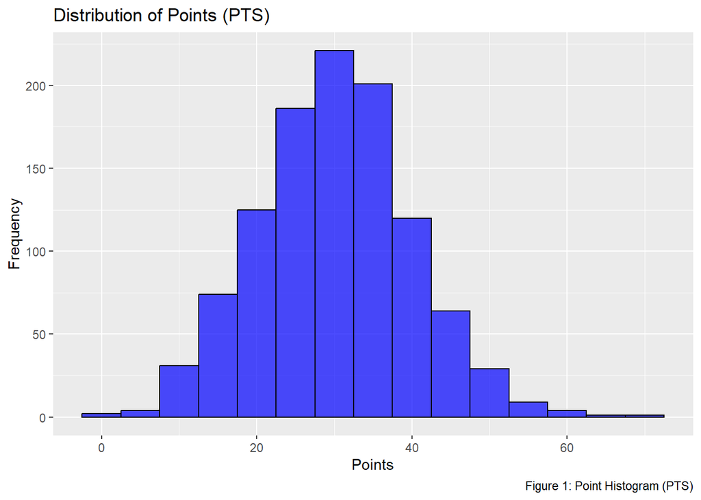

```r
# Point Histogram (PTS):
ggplot(Michael_df, aes(x = pts)) +
  geom_histogram(binwidth = 5, fill = "blue", color = "black", alpha = 0.7) +
  labs(title = "Distribution of Points (PTS)",
       x = "Points",
       y = "Frequency",
       caption = "Figure 1: Point Histogram (PTS)")
```

This histogram (Figure 1) displays the highest frequency of Michael Jordan scored within a specific point range. Each bar in the histogram represents a range of points.

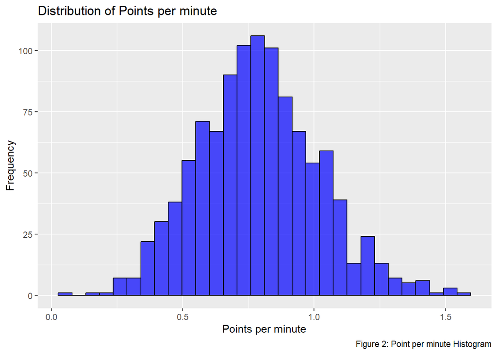

```r
ggplot(Michael_df, aes(x = pts_per_minute)) +
  geom_histogram(fill = "blue", color = "black", alpha = 0.7) +
  labs(title = "Distribution of Points per minute",
       x = "Points per minute",
       y = "Frequency",
       caption = "Figure 2: Point per minute Histogram")
```

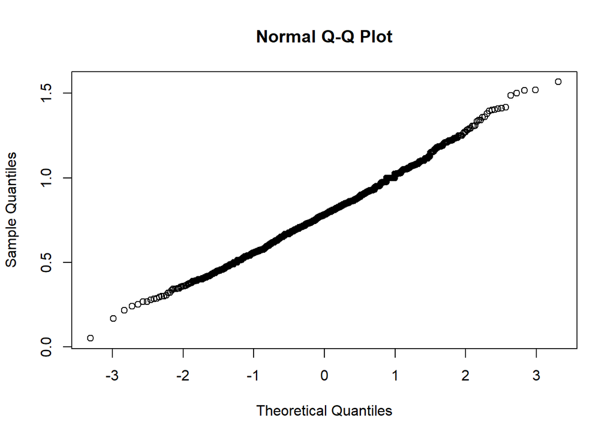

```r
plot(qqnorm(Michael_df$pts_per_minute),
     main = "Normal Q-Q Plot")
```